# Project: Investigate a Dataset (Medical Appointment No Shows)

- Introduction
- Data Wrangling
- Exploratory Data Analysis
- Conclusions

## Introduction

This dataset collects information from 100k medical appointments in Brazil and is focused on the question of whether

or not patients show up for their appointment. A number of characteristics about the patient are included in each row.

● ‘ScheduledDay’ tells us on what day the patient set up their appointment.

● ‘Neighborhood’ indicates the location of the hospital.

● ‘Scholarship’ indicates whether or not the patient is enrolled in Brasilian welfare program Bolsa Família.

● Be careful about the encoding of the last column: it says ‘No’ if the patient showed up to their appointment, and ‘Yes’ if they did not show up.

Questions :

1- Does receiveing a sms affect in the attendance of patients?

- by answering this question, we will understand if there is a correlation between receiving our patients a sms and attendance the appointment, if the answer is yes than we should make sure that our future patients will receive a sms to attend our medical appointment.

2- Is there a relation between having scholarship and attendance?

- by answering this question, we will explore if most of our patients who attend the appointment have a scholarship or there is no relation, from the answer of this question we will know our patients more and find out if the patients that have a scholarship are more intersted in this appointment or not.

3- Is there a correlation between age and having deseases affect in the attendance of patients?

4- Is there a correlation between gender and attendance of patients?

- by answering this question, we will find out if male are more interested in attending this appointment or the reverse is true or they are same.If the answer tell us they are not the same so we will try to find the reason of this case. Do we need to improve our sevices?

```python
# Use this cell to set up import statements for all of the packages that you
#   plan to use.
import pandas as pd
import numpy as np
import matplotlib.pyplot as plt
import seaborn as sns
%matplotlib inline
# Remember to include a 'magic word' so that your visualizations are plotted
#   inline with the notebook. See this page for more:
#   http://ipython.readthedocs.io/en/stable/interactive/magics.html
```

## Data Wrangling

### General Properties

#### Some information about data we have

```python
# Load your data and print out a few lines. Perform operations to inspect data
#   types and look for instances of missing or possibly errant data.
df = pd.read_csv('noshowappointments-kagglev2-may-2016.csv')
df.head()
```

|  | PatientId | AppointmentID | Gender | ScheduledDay | AppointmentDay | Age | Neighbourhood | Scholarship | Hipertension | Diabetes | Alcoholism | Handcap | SMS_received | No-show |
| --- | --- | --- | --- | --- | --- | --- | --- | --- | --- | --- | --- | --- | --- | --- |
| 0 | 2.987250e+13 | 5642903 | F | 2016-04-29T18:38:08Z | 2016-04-29T00:00:00Z | 62 | JARDIM DA PENHA | 0 | 1 | 0 | 0 | 0 | 0 | No |
| 1 | 5.589978e+14 | 5642503 | M | 2016-04-29T16:08:27Z | 2016-04-29T00:00:00Z | 56 | JARDIM DA PENHA | 0 | 0 | 0 | 0 | 0 | 0 | No |
| 2 | 4.262962e+12 | 5642549 | F | 2016-04-29T16:19:04Z | 2016-04-29T00:00:00Z | 62 | MATA DA PRAIA | 0 | 0 | 0 | 0 | 0 | 0 | No |
| 3 | 8.679512e+11 | 5642828 | F | 2016-04-29T17:29:31Z | 2016-04-29T00:00:00Z | 8 | PONTAL DE CAMBURI | 0 | 0 | 0 | 0 | 0 | 0 | No |
| 4 | 8.841186e+12 | 5642494 | F | 2016-04-29T16:07:23Z | 2016-04-29T00:00:00Z | 56 | JARDIM DA PENHA | 0 | 1 | 1 | 0 | 0 | 0 | No |

```python
df.shape
```

```
(110527, 14)
```

```python
df.info()
```

```
<class 'pandas.core.frame.DataFrame'>
RangeIndex: 110527 entries, 0 to 110526
Data columns (total 14 columns):
 #   Column          Non-Null Count   Dtype
---  ------          --------------   -----
 0   PatientId       110527 non-null  float64
 1   AppointmentID   110527 non-null  int64
 2   Gender          110527 non-null  object
 3   ScheduledDay    110527 non-null  object
 4   AppointmentDay  110527 non-null  object
 5   Age             110527 non-null  int64
 6   Neighbourhood   110527 non-null  object
 7   Scholarship     110527 non-null  int64
 8   Hipertension    110527 non-null  int64
 9   Diabetes        110527 non-null  int64
 10  Alcoholism      110527 non-null  int64
 11  Handcap         110527 non-null  int64
 12  SMS_received    110527 non-null  int64
 13  No-show         110527 non-null  object
dtypes: float64(1), int64(8), object(5)
memory usage: 11.8+ MB
```

```python
df.isnull().sum()
```

```
PatientId         0
AppointmentID     0
Gender            0
ScheduledDay      0
AppointmentDay    0
Age               0
Neighbourhood     0
Scholarship       0
Hipertension      0
Diabetes          0
Alcoholism        0
Handcap           0
SMS_received      0
No-show           0
dtype: int64
```

```python
df.duplicated().sum()
```

```
0
```

```python
df.describe()
```

|  | PatientId | AppointmentID | Age | Scholarship | Hipertension | Diabetes | Alcoholism | Handcap | SMS_received |
| --- | --- | --- | --- | --- | --- | --- | --- | --- | --- |
| count | 1.105270e+05 | 1.105270e+05 | 110527.000000 | 110527.000000 | 110527.000000 | 110527.000000 | 110527.000000 | 110527.000000 | 110527.000000 |
| mean | 1.474963e+14 | 5.675305e+06 | 37.088874 | 0.098266 | 0.197246 | 0.071865 | 0.030400 | 0.022248 | 0.321026 |
| std | 2.560949e+14 | 7.129575e+04 | 23.110205 | 0.297675 | 0.397921 | 0.258265 | 0.171686 | 0.161543 | 0.466873 |
| min | 3.921784e+04 | 5.030230e+06 | -1.000000 | 0.000000 | 0.000000 | 0.000000 | 0.000000 | 0.000000 | 0.000000 |
| 25% | 4.172614e+12 | 5.640286e+06 | 18.000000 | 0.000000 | 0.000000 | 0.000000 | 0.000000 | 0.000000 | 0.000000 |
| 50% | 3.173184e+13 | 5.680573e+06 | 37.000000 | 0.000000 | 0.000000 | 0.000000 | 0.000000 | 0.000000 | 0.000000 |
| 75% | 9.439172e+13 | 5.725524e+06 | 55.000000 | 0.000000 | 0.000000 | 0.000000 | 0.000000 | 0.000000 | 1.000000 |
| max | 9.999816e+14 | 5.790484e+06 | 115.000000 | 1.000000 | 1.000000 | 1.000000 | 1.000000 | 4.000000 | 1.000000 |

#### From the information i get from the data, I found there is a mistake in the name of some columns in data like

#### Hipertenstion ,It must be Hypertension and also Handcap, It must be Handicap.

#### There is no duplicated rows or any missing values.

#### There is incorrect data and outliers in age.

#### There is incorrect type of some data.

### Data Cleaning (Fixing some problems in data)

#### Rename the incorrect columns

```python
# After discussing the structure of the data and any problems that need to be
#   cleaned, perform those cleaning steps in the second part of this section.
df.rename(columns={'Hipertension': 'Hypertension', 'Handcap': 'Handicap'}, inplace=True)
df.rename(columns=lambda x: x.strip().replace('-','_'), inplace=True)
df.head()
```

|  | PatientId | AppointmentID | Gender | ScheduledDay | AppointmentDay | Age | Neighbourhood | Scholarship | Hypertension | Diabetes | Alcoholism | Handicap | SMS_received | No_show |
| --- | --- | --- | --- | --- | --- | --- | --- | --- | --- | --- | --- | --- | --- | --- |
| 0 | 2.987250e+13 | 5642903 | F | 2016-04-29T18:38:08Z | 2016-04-29T00:00:00Z | 62 | JARDIM DA PENHA | 0 | 1 | 0 | 0 | 0 | 0 | No |
| 1 | 5.589978e+14 | 5642503 | M | 2016-04-29T16:08:27Z | 2016-04-29T00:00:00Z | 56 | JARDIM DA PENHA | 0 | 0 | 0 | 0 | 0 | 0 | No |
| 2 | 4.262962e+12 | 5642549 | F | 2016-04-29T16:19:04Z | 2016-04-29T00:00:00Z | 62 | MATA DA PRAIA | 0 | 0 | 0 | 0 | 0 | 0 | No |
| 3 | 8.679512e+11 | 5642828 | F | 2016-04-29T17:29:31Z | 2016-04-29T00:00:00Z | 8 | PONTAL DE CAMBURI | 0 | 0 | 0 | 0 | 0 | 0 | No |
| 4 | 8.841186e+12 | 5642494 | F | 2016-04-29T16:07:23Z | 2016-04-29T00:00:00Z | 56 | JARDIM DA PENHA | 0 | 1 | 1 | 0 | 0 | 0 | No |

#### Remove the incorrect data and the outliers of age

```python
df.query('Age < 0')
```

|  | PatientId | AppointmentID | Gender | ScheduledDay | AppointmentDay | Age | Neighbourhood | Scholarship | Hypertension | Diabetes | Alcoholism | Handicap | SMS_received | No_show |
| --- | --- | --- | --- | --- | --- | --- | --- | --- | --- | --- | --- | --- | --- | --- |
| 99832 | 4.659432e+14 | 5775010 | F | 2016-06-06T08:58:13Z | 2016-06-06T00:00:00Z | -1 | ROMÃO | 0 | 0 | 0 | 0 | 0 | 0 | No |

```python
df.drop(index=99832, inplace=True)
```

```python
df.query('Age > 100')
```

|  | PatientId | AppointmentID | Gender | ScheduledDay | AppointmentDay | Age | Neighbourhood | Scholarship | Hypertension | Diabetes | Alcoholism | Handicap | SMS_received | No_show |
| --- | --- | --- | --- | --- | --- | --- | --- | --- | --- | --- | --- | --- | --- | --- |
| 58014 | 9.762948e+14 | 5651757 | F | 2016-05-03T09:14:53Z | 2016-05-03T00:00:00Z | 102 | CONQUISTA | 0 | 0 | 0 | 0 | 0 | 0 | No |
| 63912 | 3.196321e+13 | 5700278 | F | 2016-05-16T09:17:44Z | 2016-05-19T00:00:00Z | 115 | ANDORINHAS | 0 | 0 | 0 | 0 | 1 | 0 | Yes |
| 63915 | 3.196321e+13 | 5700279 | F | 2016-05-16T09:17:44Z | 2016-05-19T00:00:00Z | 115 | ANDORINHAS | 0 | 0 | 0 | 0 | 1 | 0 | Yes |
| 68127 | 3.196321e+13 | 5562812 | F | 2016-04-08T14:29:17Z | 2016-05-16T00:00:00Z | 115 | ANDORINHAS | 0 | 0 | 0 | 0 | 1 | 0 | Yes |
| 76284 | 3.196321e+13 | 5744037 | F | 2016-05-30T09:44:51Z | 2016-05-30T00:00:00Z | 115 | ANDORINHAS | 0 | 0 | 0 | 0 | 1 | 0 | No |
| 90372 | 2.342836e+11 | 5751563 | F | 2016-05-31T10:19:49Z | 2016-06-02T00:00:00Z | 102 | MARIA ORTIZ | 0 | 0 | 0 | 0 | 0 | 0 | No |
| 97666 | 7.482346e+14 | 5717451 | F | 2016-05-19T07:57:56Z | 2016-06-03T00:00:00Z | 115 | SÃO JOSÉ | 0 | 1 | 0 | 0 | 0 | 1 | No |

```python
df.drop(index=58014, inplace=True)
df.drop(index=63912, inplace=True)
df.drop(index=63915, inplace=True)
df.drop(index=68127, inplace=True)
df.drop(index=76284, inplace=True)
df.drop(index=90372, inplace=True)
df.drop(index=97666, inplace=True)
```

```python
df.query('Age > 100')
```

|  | PatientId | AppointmentID | Gender | ScheduledDay | AppointmentDay | Age | Neighbourhood | Scholarship | Hypertension | Diabetes | Alcoholism | Handicap | SMS_received | No_show |
| --- | --- | --- | --- | --- | --- | --- | --- | --- | --- | --- | --- | --- | --- | --- |

```python
df.query('Age < 0')
```

|  | PatientId | AppointmentID | Gender | ScheduledDay | AppointmentDay | Age | Neighbourhood | Scholarship | Hypertension | Diabetes | Alcoholism | Handicap | SMS_received | No_show |
| --- | --- | --- | --- | --- | --- | --- | --- | --- | --- | --- | --- | --- | --- | --- |

```python
df.describe()
```

|  | PatientId | AppointmentID | Age | Scholarship | Hypertension | Diabetes | Alcoholism | Handicap | SMS_received |
| --- | --- | --- | --- | --- | --- | --- | --- | --- | --- |
| count | 1.105190e+05 | 1.105190e+05 | 110519.000000 | 110519.000000 | 110519.000000 | 110519.000000 | 110519.000000 | 110519.000000 | 110519.000000 |
| mean | 1.474860e+14 | 5.675303e+06 | 37.084519 | 0.098273 | 0.197251 | 0.071870 | 0.030402 | 0.022213 | 0.321040 |
| std | 2.560826e+14 | 7.129600e+04 | 23.103165 | 0.297684 | 0.397925 | 0.258274 | 0.171692 | 0.161441 | 0.466878 |
| min | 3.921784e+04 | 5.030230e+06 | 0.000000 | 0.000000 | 0.000000 | 0.000000 | 0.000000 | 0.000000 | 0.000000 |
| 25% | 4.172457e+12 | 5.640284e+06 | 18.000000 | 0.000000 | 0.000000 | 0.000000 | 0.000000 | 0.000000 | 0.000000 |
| 50% | 3.172598e+13 | 5.680569e+06 | 37.000000 | 0.000000 | 0.000000 | 0.000000 | 0.000000 | 0.000000 | 0.000000 |
| 75% | 9.438963e+13 | 5.725522e+06 | 55.000000 | 0.000000 | 0.000000 | 0.000000 | 0.000000 | 0.000000 | 1.000000 |
| max | 9.999816e+14 | 5.790484e+06 | 100.000000 | 1.000000 | 1.000000 | 1.000000 | 1.000000 | 4.000000 | 1.000000 |

#### correct type of some data

```python
#correct type of ScheduledDay and AppointmentDay.
df['ScheduledDay'] = df['ScheduledDay'].astype('datetime64[ns]')
df['AppointmentDay'] = df['AppointmentDay'].astype('datetime64[ns]')
df.info()
```

```
<class 'pandas.core.frame.DataFrame'>
Int64Index: 110519 entries, 0 to 110526
Data columns (total 14 columns):
 #   Column          Non-Null Count   Dtype
---  ------          --------------   -----
 0   PatientId       110519 non-null  float64
 1   AppointmentID   110519 non-null  int64
 2   Gender          110519 non-null  object
 3   ScheduledDay    110519 non-null  datetime64[ns]
 4   AppointmentDay  110519 non-null  datetime64[ns]
 5   Age             110519 non-null  int64
 6   Neighbourhood   110519 non-null  object
 7   Scholarship     110519 non-null  int64
 8   Hypertension    110519 non-null  int64
 9   Diabetes        110519 non-null  int64
 10  Alcoholism      110519 non-null  int64
 11  Handicap        110519 non-null  int64
 12  SMS_received    110519 non-null  int64
 13  No_show         110519 non-null  object
dtypes: datetime64[ns](2), float64(1), int64(8), object(3)
memory usage: 12.6+ MB
```

```python
df.head()
```

|  | PatientId | AppointmentID | Gender | ScheduledDay | AppointmentDay | Age | Neighbourhood | Scholarship | Hypertension | Diabetes | Alcoholism | Handicap | SMS_received | No_show |
| --- | --- | --- | --- | --- | --- | --- | --- | --- | --- | --- | --- | --- | --- | --- |
| 0 | 2.987250e+13 | 5642903 | F | 2016-04-29 18:38:08 | 2016-04-29 | 62 | JARDIM DA PENHA | 0 | 1 | 0 | 0 | 0 | 0 | No |
| 1 | 5.589978e+14 | 5642503 | M | 2016-04-29 16:08:27 | 2016-04-29 | 56 | JARDIM DA PENHA | 0 | 0 | 0 | 0 | 0 | 0 | No |
| 2 | 4.262962e+12 | 5642549 | F | 2016-04-29 16:19:04 | 2016-04-29 | 62 | MATA DA PRAIA | 0 | 0 | 0 | 0 | 0 | 0 | No |
| 3 | 8.679512e+11 | 5642828 | F | 2016-04-29 17:29:31 | 2016-04-29 | 8 | PONTAL DE CAMBURI | 0 | 0 | 0 | 0 | 0 | 0 | No |
| 4 | 8.841186e+12 | 5642494 | F | 2016-04-29 16:07:23 | 2016-04-29 | 56 | JARDIM DA PENHA | 0 | 1 | 1 | 0 | 0 | 0 | No |

## Exploratory Data Analysis

### Research Question 1 (Does receiving a sms affect in the attendance?)

#### General Vision

```
array([[<AxesSubplot:title={'center':'PatientId'}>,
        <AxesSubplot:title={'center':'AppointmentID'}>,
        <AxesSubplot:title={'center':'ScheduledDay'}>],
       [<AxesSubplot:title={'center':'AppointmentDay'}>,
        <AxesSubplot:title={'center':'Age'}>,
        <AxesSubplot:title={'center':'Scholarship'}>],
       [<AxesSubplot:title={'center':'Hypertension'}>,
        <AxesSubplot:title={'center':'Diabetes'}>,
        <AxesSubplot:title={'center':'Alcoholism'}>],
       [<AxesSubplot:title={'center':'Handicap'}>,
        <AxesSubplot:title={'center':'SMS_received'}>, <AxesSubplot:>]],
      dtype=object)
```

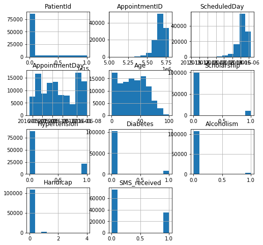

```python
# Use this, and more code cells, to explore your data. Don't forget to add
#   Markdown cells to document your observations and findings.
df.hist(figsize=(8, 8))
```

#### We try to find out if receiving a sms is that important in attendance of our patients

```python
#number of patients who attended the appointment and who didn't show up
df['No_show'].value_counts()
```

```
No     88203
Yes    22316
Name: No_show, dtype: int64
```

```python
#divide the patients into 2 groups attendance and absent
attendance = df['No_show'] == 'No'
absent = df['No_show'] == 'Yes'
```

```python
#number of patients who received a sms and who didn't receive any thing
df['SMS_received'].value_counts()
```

```
0    75038
1    35481
Name: SMS_received, dtype: int64
```

#### Most of patients didn't receive a sms

```python
#mean of SMS_received according to attendance
df.SMS_received[attendance].mean()
```

```
0.29133929684931353
```

```python
#mean of SMS_received according to absent
df.SMS_received[absent].mean()
```

```
0.4384298261337157
```

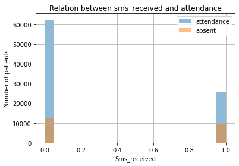

```python
#find out the relation between sms_received and attendance
df.SMS_received[attendance].hist(alpha=0.5, bins=20, label='attendance')
df.SMS_received[absent].hist(alpha=0.5, bins=20, label='absent')
plt.title('Relation between sms_received and attendance')
plt.xlabel('Sms_received')
plt.ylabel('Number of patients')
plt.legend();
```

#### It seems like the number of patients who attend the appointment didn't receive a sms is greater than those who received a sms , we see that from the visualization we create, in the x-axis 0 means no sms and 1 means that the patient receive a sms.

### Research Question 2 (Is there a relation between scholarship and attendance?)

#### We try to find out if the patients who having a scholarship are more interesed in this appointment

```python
#number of patients who having a scholarship and who didn't have it
df.Scholarship.value_counts()
```

```
0    99658
1    10861
Name: Scholarship, dtype: int64
```

#### Most of patients doesn't have a scholarship¶

```python
#number of patients who having a scholarship or not according to attendance
df.Scholarship[attendance].value_counts()
```

```
0    79920
1     8283
Name: Scholarship, dtype: int64
```

```python
#number of patients who having a scholarship or not according to absent
df.Scholarship[absent].value_counts()
```

```
0    19738
1     2578
Name: Scholarship, dtype: int64
```

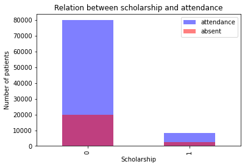

```python
#find out the effect of having a scholarship in the attendance
df.Scholarship[attendance].value_counts().plot(kind='bar',alpha=0.5, color= 'blue', label='attendance')
df.Scholarship[absent].value_counts().plot(kind='bar',alpha=0.5, color= 'red', label='absent')
plt.title('Relation between scholarship and attendance')
plt.xlabel('Scholarship')
plt.ylabel('Number of patients')
plt.legend();
```

#### It is clear that the patients who have not a scholarship is more likely attended the appointment than those who have it, in the x-axis 0 means the patient have not a scholarship and 1 means the patient have a sholarship.

### Research Question 3 (Is there a correlation between age and having deseases affect in the attendance of patients?)

```python
#find out the correlation between age and having deseases according to attendance
df[attendance].groupby(['Hypertension', 'Diabetes']).Age.mean()
```

```
Hypertension  Diabetes
0             0           31.507180
              1           53.666952
1             0           59.697784
              1           63.406361
Name: Age, dtype: float64
```

```python
#find out the correlation between age and having deseases according to absent
df[absent].groupby(['Hypertension', 'Diabetes']).Age.mean()
```

```
Hypertension  Diabetes
0             0           28.819995
              1           49.183391
1             0           58.377043
              1           62.820333
Name: Age, dtype: float64
```

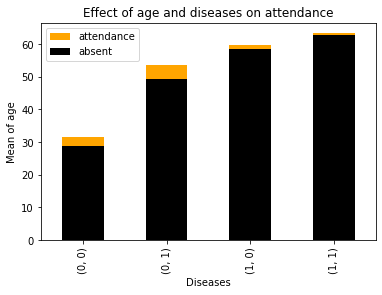

```python
#find out the effect of age and having deseases in the attendance
df[attendance].groupby(['Hypertension', 'Diabetes']).Age.mean().plot(kind='bar', color='orange', label='attendance')
df[absent].groupby(['Hypertension', 'Diabetes']).Age.mean().plot(kind='bar', color='black', label='absent')
plt.xlabel('Diseases')
plt.ylabel('Mean of age')
plt.title('Effect of age and diseases on attendance')
plt.legend();
```

### Research Question 4 (Is there a correlation between gender and attendance of patients?)

```python
#number of females and males who have taken appointment to attend
df.groupby('Gender').No_show.count()
```

```
Gender
F    71832
M    38687
Name: No_show, dtype: int64
```

```python
#number of females and males who actually attended the appointment
df[attendance].Gender.value_counts()
```

```
F    57241
M    30962
Name: Gender, dtype: int64
```

```python
#number of females and males who didn't attended the appointment
df[absent].Gender.value_counts()
```

```
F    14591
M     7725
Name: Gender, dtype: int64
```

#### We try to find out if the gender of patient affect in his attendance

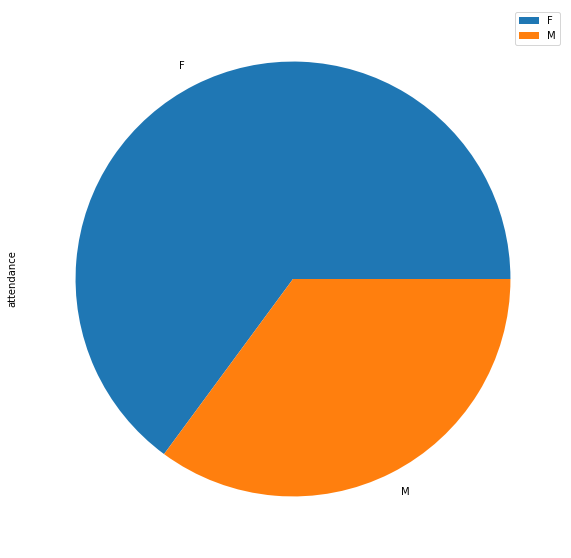

```python
df[attendance].Gender.value_counts().plot(kind='pie', figsize=(15,10), label='attendance')
plt.legend();
```

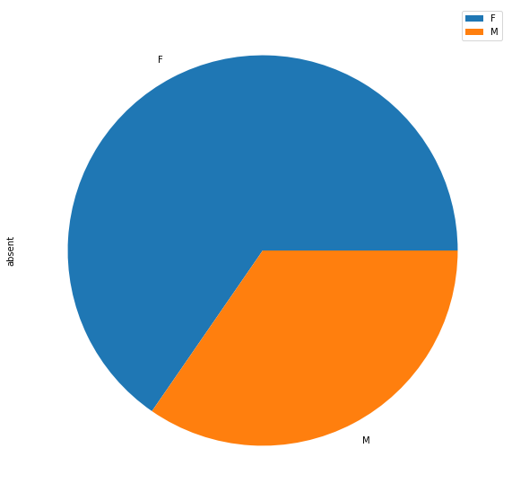

```python
df[absent].Gender.value_counts().plot(kind='pie', figsize=(15,10), label='absent')
plt.legend();
```